# I. Overview

```python
import numpy as np
import pandas as pd
import matplotlib.pyplot as plt
import seaborn as sns
from sklearn.feature_extraction.text import TfidfVectorizer
import nltk
import re
import string
from wordcloud import WordCloud

from nltk.tokenize import word_tokenize
from nltk.stem import WordNetLemmatizer

%matplotlib inline
```

```python
#read file
df= pd.read_csv('Talent_Snapshot.csv')
```

```python
df.shape
```

```
(3310, 15)
```

```python
df.head()
```

|  | Submitted On | Education | Skillset | What do you want to work | Teammate or not | Remotely or not | Start date | Platforms interested in | Pick Your Startups | Pick Your Teams | How you can add value | Biggest Achievement | Your ideal job | What we know about you that we didnt ask you | Unnamed: 14 |
| --- | --- | --- | --- | --- | --- | --- | --- | --- | --- | --- | --- | --- | --- | --- | --- |
| 0 | 1 | Santa Clara University | More than technical skills, I would say am goo... | My prior experience was different from what I ... | Doesn't matter. | If it’s an option, I don't mind working remotely. | NaN | NaN | NaN | NaN | NaN | NaN | NaN | NaN | NaN |
| 1 | 2 | University of California, Riverside | In regards to my talents, I have a strong bac... | I hope to work in the data science field to p... | Working as a team or working by myself are bot... | Commuting to and from work is not an issue sin... | NaN | NaN | NaN | NaN | NaN | NaN | NaN | NaN | NaN |
| 2 | 3 | University of California, Berkeley | I have exceptional time management skills. As ... | Though I am relatively new to programming as I... | Though I believe I am able to handle either, I... | No, I will not be working remotely. | NaN | NaN | NaN | NaN | NaN | NaN | NaN | NaN | NaN |
| 3 | 4 | San Jose State University | I am goo with Back-end development and Machine... | I want to work on any kind of software develop... | Doesn't Matter, but prefer working on team | I am fine with anything | NaN | NaN | NaN | NaN | NaN | NaN | NaN | NaN | NaN |
| 4 | 5 | University of California, San Diego | I'm talented at self-control. I would finish m... | I would like to know more people in the workpl... | I would prefer working individually on a small... | Because I'm still studying in UC San Diego, I ... | NaN | NaN | NaN | NaN | NaN | NaN | NaN | NaN | NaN |

```python
df.info()
```

```
<class 'pandas.core.frame.DataFrame'>
RangeIndex: 3310 entries, 0 to 3309
Data columns (total 15 columns):
Submitted On                                    3310 non-null object
Education                                       3252 non-null object
Skillset                                        3309 non-null object
What do you want to work                        3306 non-null object
Teammate or not                                 3250 non-null object
Remotely or not                                 3247 non-null object
Start date                                      2754 non-null object
Platforms interested in                         1194 non-null object
Pick Your Startups                              2487 non-null object
Pick Your Teams                                 2487 non-null object
How you can add value                           333 non-null object
Biggest Achievement                             348 non-null object
Your ideal job                                  1014 non-null object
What we know about you that we didnt ask you    1480 non-null object
Unnamed: 14                                     0 non-null float64
dtypes: float64(1), object(14)
memory usage: 388.0+ KB
```

Although there are 3310 observations, there are a lot null values in each column. This means not every candidate finished all of the questions.

# II. Part 1 - Talent Analysis

# 1. Education

```python
df['Education'].value_counts()
```

```
University of California, San Diego                                                                                                                                                                                   39
University of California, Los Angeles                                                                                                                                                                                 27
Syracuse University                                                                                                                                                                                                   18
Data Analytics, Marketing & Programming                                                                                                                                                                               16
Carnegie Mellon University                                                                                                                                                                                            16
                                                                                                                                                                                                                      ..
University of Arkansas/BSBA Economics & German                                                                                                                                                                         1
University of San Diego Business Economics                                                                                                                                                                             1
University Of California San Diego/M.S. Electrical and Computer Engineering, Birla Institute Of Technology and Science(BITS) Pilani/B.E.(Hons.) Electronics and Instrumentation & M.S.(Hons.) Biological Sciences,     1
Georgetown University, M.S. in Data Analytics/ University of California, Irvine, B.S. in Mechanical Engineering                                                                                                        1
Southern Methodist University - BBA in Finance, BS in Statistical Science; High School Affiliated to Shanghai Jiao Tong University - International Baccalaureate Diploma (High School Diploma)                         1
Name: Education, Length: 2747, dtype: int64
```

```python
sum(df.duplicated())
```

```
0
```

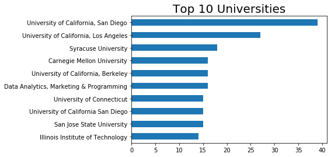

```python
df['Education'].value_counts()[0:10].sort_values(ascending=True).plot(kind = 'barh')
plt.title('Top 10 Universities', size=20)
```

```python
df['Education']=df['Education'].apply(str)
```

```python
skill_text = df.Skillset.values
```

```python
Education_text = df.Education.values
```

```python
# Create a regex search function
def count_text(patt,Education_text):
    pattern = re.compile(patt)
    count = 0
    for t in Education_text:
        if pattern.search(t):
            count+=1
    return count
```

```python
# Define regex pattern and seach for PhD
pattern = re.compile('(?i)\WPh.?D\W')
pattern2 = re.compile('(?i)\WDoctorate\W')
pattern3= re.compile('(?i)\WPhD\W')
count = 0
for t in Education_text:
    if pattern.search(t):
        count +=1
    elif pattern2.search(t):
        count +=1
degree = {"PhD": [count]}
```

```python
# Define regex pattern and seach for Master
pattern = re.compile("(?i)\WMasters?'?s?\W")
pattern2 = re.compile('(?i)\WM.?S\W')
pattern3 = re.compile('(?i)\WMS\W')
count = 0
for t in Education_text:
    if pattern.search(t):
        count +=1
    elif pattern2.search(t):
        count +=1
    elif pattern3.search(t):
        count +=1
degree.update({"Master":[count]})
```

```python
# Define regex pattern and seach for MBA
pattern = re.compile("(?i)\WMBA\W")

count = 0
for t in Education_text:
    if pattern.search(t):
        count +=1
degree.update({"MBA":[count]})
```

```python
# Define regex pattern and seach for Bachelor
pattern = re.compile("(?i)\WBachelors?'?s?\W")
pattern2 = re.compile('(?i)\WB.?S\W')
pattern3 = re.compile('(?i)\WBS\W')
pattern4 = re.compile('(?i)\WBA\W')
pattern5 = re.compile('(?i)\WB.A\W')
count = 0
for t in Education_text:
    if pattern.search(t):
        count +=1
    elif pattern2.search(t):
        count +=1
    elif pattern3.search(t):
        count +=1
    elif pattern4.search(t):
        count +=1
    elif pattern5.search(t):
        count +=1

degree.update({"Bachelor": [count]})
```

```python
degree = pd.DataFrame.from_dict(degree,orient='index',
                       columns=['count'])
degree['ptg'] = degree['count']/len(Education_text)
```

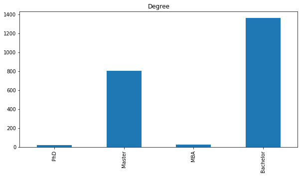

```python
ax =degree['count'].plot(kind = "bar", figsize =(10,5))
ax.set_title('Degree')
ax.set_xticklabels(degree.index)
plt.show()
```

```python
degree
```

|  | count | ptg |
| --- | --- | --- |
| PhD | 21 | 0.006344 |
| Master | 803 | 0.242598 |
| MBA | 26 | 0.007855 |
| Bachelor | 1362 | 0.411480 |

Forkaia should be proud to say that there are 21 PhD, 803 Master, 26 MBA and more than 1300 Bachelor candidates have applied to the company. Regarding percentage, 24% of students would like to work for Forkaia are currently pursuing Master of Science degree. Also, more than 40% have completed or are currently studying Bachelors.

# 2. Job Titles

Computer Scientist, Data Scientist, Software Engineer are those titles that the company would like to showcase. Job Title can be retrieved from different columns including

- “Your ideal job”
- “Pick your Team”
- major in “Education”.

# "Your ideal job" Column

```python
df['Your ideal job'].value_counts()
```

```
Data Scientist                                                                                                                       34
Data Analyst                                                                                                                         13
Data scientist                                                                                                                       10
Business Analyst                                                                                                                      4
Data analyst                                                                                                                          3
                                                                                                                                     ..
My ideal job would be that which will be help me in continuous learning and creative work in Machine Learning and Data Analytics.     1
Working in a development team with professional team members that ready to support me.                                                1
Fantasy job                                                                                                                           1
Data scientist/analyst working on projects that make a difference or has potential to do so.                                          1
Working on marketing specifically on social media and doing market research, finding the best strategies for startup companies.       1
Name: Your ideal job, Length: 923, dtype: int64
```

```python
df['Your ideal job']=df['Your ideal job'].apply(str)
```

```python
IdealJob_text = df['Your ideal job'].values
```

```python
# Create a regex search function
def count_text(patt,IdealJob_text):
    pattern = re.compile(patt)
    count = 0
    for t in IdealJob_text:
        if pattern.search(t):
            count+=1
    return count
```

```python
# Define regex pattern and seach for Data Scientist
pattern = re.compile('(?i)\WData Scientist\W')
pattern2 = re.compile('(?i)\WData scientist\W')
pattern3 = re.compile('(?i)\WData science\W')
pattern4 = re.compile('(?i)\WData Science\W')
count = 0
for t in IdealJob_text:
    if pattern.search(t):
        count +=1
    elif pattern2.search(t):
        count +=1
    elif pattern3.search(t):
        count +=1
    elif pattern4.search(t):
        count +=1
IdealJob = {"Data Scientist":[count]}
```

```python
# Define regex pattern and seach for Data Analyst
pattern = re.compile('(?i)\WData Analyst\W')
pattern2 = re.compile('(?i)\WData analyst\W')
pattern3 = re.compile('(?i)\WBusiness analyst\W')
pattern4 = re.compile('(?i)\WBusiness Analyst\W')
pattern5 = re.compile('(?i)\WData Analytics\W')
pattern6 = re.compile('(?i)\WBusiness Analytics\W')
count = 0
for t in IdealJob_text:
    if pattern.search(t):
        count +=1
    elif pattern2.search(t):
        count +=1
    elif pattern3.search(t):
        count +=1
    elif pattern4.search(t):
        count +=1
    elif pattern5.search(t):
        count +=1
    elif pattern6.search(t):
        count +=1
IdealJob.update({"Data Analyst":[count]})
```

```python
# Define regex pattern and seach for Software Engineer
pattern = re.compile('(?i)\WSoftware Engineer\W')
pattern2 = re.compile('(?i)\WDeveloper\W')
pattern3 = re.compile('(?i)\WSoftware Development\W')
count = 0
for t in IdealJob_text:
    if pattern.search(t):
        count +=1
    elif pattern2.search(t):
        count +=1
    elif pattern3.search(t):
        count +=1
IdealJob.update({"Software Engineer":[count]})
```

```python
# Define regex pattern and seach for Computer Scientist
pattern = re.compile('(?i)\WComputer Science\W')
pattern2 = re.compile('(?i)\WComputer Scientist\W')
count = 0
for t in IdealJob_text:
    if pattern.search(t):
        count +=1
    elif pattern2.search(t):
        count +=1
IdealJob.update({"Computer Scientist":[count]})
```

```python
IdealJob = pd.DataFrame.from_dict(IdealJob,orient='index', columns=['count'])
```

```python
IdealJob
```

|  | count |
| --- | --- |
| Data Scientist | 49 |
| Data Analyst | 49 |
| Software Engineer | 35 |
| Computer Scientist | 3 |

# Major values in Education column

```python
# Define regex pattern and seach for Computer Scientist
pattern = re.compile("(?i)\WComputer Science?'?s?\W")
pattern2 = re.compile("(?i)\WComputer science?'?s?\W")
count = 0
for t in Education_text:
    if pattern.search(t):
        count +=1
    elif pattern2.search(t):
        count +=1
CS = {"Computer Scientist": [count]}
```

```python
CS
```

```
{'Computer Scientist': [313]}
```

```python
# Define regex pattern and seach for Software Engineer
pattern = re.compile("(?i)\WSoftware\W")
pattern2 = re.compile("(?i)\WWeb Development\W")
count = 0
for t in Education_text:
    if pattern.search(t):
        count +=1
    elif pattern2.search(t):
        count +=1
SW = {"Software Engineer": [count]}
```

```python
SW
```

```
{'Software Engineer': [34]}
```

```python
# Define regex pattern and seach for Data Science
pattern = re.compile("(?i)\WAnalytic?'?s?\W")
pattern2 = re.compile("(?i)\WMathemmatic?'?s?\W")
pattern3 = re.compile('(?i)\WQuantitative\W')
pattern4 = re.compile('(?i)\WStatistics\W')
pattern5 = re.compile('(?i)\WData Science\W')
count = 0
for t in Education_text:
    if pattern.search(t):
        count +=1
    elif pattern2.search(t):
        count +=1
    elif pattern3.search(t):
        count +=1
    elif pattern4.search(t):
        count +=1
    elif pattern5.search(t):
        count +=1
DS = {"Data Scientist": [count]}
```

```python
DS
```

```
{'Data Scientist': [535]}
```

# Data & Dev Team counting in "Pick Your Team"

```python
df['Pick Your Teams']=df['Pick Your Teams'].apply(str)
```

```python
Team_text = df['Pick Your Teams'].values
```

```python
# Create a regex search function
def count_text(patt,Team_text):
    pattern = re.compile(patt)
    count = 0
    for t in Team_text:
        if pattern.search(t):
            count+=1
    return count
```

```python
# Define regex pattern and seach for PhD
pattern = re.compile('(?i)\WTEAM 4 - Data - Mining & Gathering\W')
pattern2 = re.compile('(?i)\WDATA SCIENCE TEAM\W')
count = 0
for t in Team_text:
    if pattern.search(t):
        count +=1
    elif pattern2.search(t):
        count +=1
DS_Team = {"Data Science": [count]}
```

```python
DS_Team
```

```
{'Data Science': [802]}
```

```python
# Define regex pattern and seach for PhD
pattern = re.compile('(?i)\WTEAM 1 - Developers App/Mobile/Web - Back End\W')
pattern2 = re.compile('(?i)\WDEVELOPMENT TEAM\W')
pattern3 = re.compile('(?i)\WTEAM 1 - Developers App/Mobile/Web - Front End\W')
count = 0
for t in Team_text:
    if pattern.search(t):
        count +=1
    elif pattern2.search(t):
        count +=1
    elif pattern3.search(t):
        count +=1
DEV_Team = {"Developer Team": [count]}
```

```python
DEV_Team
```

```
{'Developer Team': [264]}
```

# Conclusion

To answer the question that how many data scientists, software engineers and computer scientists Forkaia have, I would like to say:

- Get the number of candidates picking Data Team for the number of Data Scientist (802 Data Scientists)
- Get the number of candidates picking Development Teams for the number of Software Engineer (264 Software Engineers)
- Get the number of candidates studying Computer Science (in “Education”) for the number of Computer Scientist (313 Computer Scientists) Reasons for choosing this approach is:
- Although the column Ideal Job has the closest meaning to the Job title, it is has least observation (just 1014 observation). A lot of values in this columns are not meaningful enough for counting number of job titles.
- Title “computer scientist” can be only retrieved from major Computer Science.
- Number of people picking the team Data and Development is the closest reflection of counting Data Scientists and Software Development because current or applied position is a better metrics to analyze than majors.

# 3. Biggest Achievement

```python
df['Biggest Achievement']=df['Biggest Achievement'].apply(str)
```

```python
Achievement_text = df['Biggest Achievement'].values
```

```python
# Create a regex search function
def count_text(patt,Achievement_text):
    pattern = re.compile(patt)
    count = 0
    for t in Achievement_text:
        if pattern.search(t):
            count+=1
    return count
```

```python
# Define regex pattern and seach for PhD
pattern = re.compile('(?i)\WHackathon\W')
pattern2 = re.compile('(?i)\Whackathon\W')
count = 0
for t in Achievement_text:
    if pattern.search(t):
        count +=1
    elif pattern2.search(t):
        count +=1
Achievement = {"Hackathon": [count]}
```

```python
Achievement
```

```
{'Hackathon': [15]}
```

Hackathon are mention 15 times in 348 observations of Biggest Achievement. However, after checking manually the meaning of 15 results mentioned Hackathon, there are only 11 people said that they have participated, won finalist rounds or prizes of Hackathon. Given the complexity of text “Analysis” Hackathon, the analyst decided not to go deeper in this parts regarding key word “Honor”or “Dean’s List”.

# 1. Skillset

```python
df['Skillset']=df['Skillset'].apply(str)
```

```python
# Create a regex search function
def count_text(patt,skill_text):
    pattern = re.compile(patt)
    count = 0
    for t in skill_text:
        if pattern.search(t):
            count+=1
    return count
```

```python
# Create a data frame with skills name and regex pattern to search with
skills = ['R','Python','Hadoop','SQL','Tableau','TensorFlow','Agile','SSaS','Algorithm','Java','Visualization','CSS','HTML','PHP', 'Linux', 'MongoDB', 'Power BI']

skill_patt = ['\WR\W+\s*','(?i)\WPython\W','(?i)\WHadoop\W?','(?i)SQL\w*','(?i)\WTableau\W?', "(?i)\WTensorFlow\W?","(?i)\WAgile\W?", "(?i)\WSSaS\W?","(?i)\WAlgorithms?\W?",'(?i)Java\w*','(?i)\WVisualization\W?', '(?i)\WCSS\W?', '(?i)\WHTML\W?', '(?i)\WPHP\W?','(?i)\WLinux\W?','(?i)\WMongoDB\W?', "(?i)\WPower\s?BI\W?"]

skill_df =pd.DataFrame(
    {"skill": skills,
     "regex_pattern":skill_patt})
```

```python
# Iterate through the list of skill using the search function created
i = []
for x in skill_df['regex_pattern']:
    i.append(count_text(x,skill_text))
skill_df['count'] = i
skill_df['ptg'] = round(skill_df['count']/len(skill_text),2)
skill_df
```

|  | skill | regex_pattern | count | ptg |
| --- | --- | --- | --- | --- |
| 0 | R | \WR\W+\s* | 488 | 0.15 |
| 1 | Python | (?i)\WPython\W | 721 | 0.22 |
| 2 | Hadoop | (?i)\WHadoop\W? | 40 | 0.01 |
| 3 | SQL | (?i)SQL\w* | 476 | 0.14 |
| 4 | Tableau | (?i)\WTableau\W? | 215 | 0.06 |
| 5 | TensorFlow | (?i)\WTensorFlow\W? | 33 | 0.01 |
| 6 | Agile | (?i)\WAgile\W? | 14 | 0.00 |
| 7 | SSaS | (?i)\WSSaS\W? | 0 | 0.00 |
| 8 | Algorithm | (?i)\WAlgorithms?\W? | 160 | 0.05 |
| 9 | Java | (?i)Java\w* | 372 | 0.11 |
| 10 | Visualization | (?i)\WVisualization\W? | 254 | 0.08 |
| 11 | CSS | (?i)\WCSS\W? | 133 | 0.04 |
| 12 | HTML | (?i)\WHTML\W? | 160 | 0.05 |
| 13 | PHP | (?i)\WPHP\W? | 32 | 0.01 |
| 14 | Linux | (?i)\WLinux\W? | 35 | 0.01 |
| 15 | MongoDB | (?i)\WMongoDB\W? | 15 | 0.00 |
| 16 | Power BI | (?i)\WPower\s?BI\W? | 52 | 0.02 |

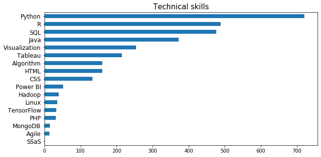

```python
x = skill_df.sort_values(by = 'count')
ax =x['count'].plot(kind = "barh",figsize = (10,5))
ax.set_title('Technical skills', size = 15)
ax.set_yticklabels(x['skill'], size = 12)
plt.show()
```

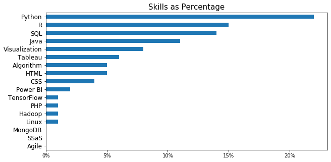

```python
x = skill_df.sort_values(by = 'ptg')
ax =x['ptg'].plot(kind = "barh",figsize = (10,5))
ax.set_title('Skills as Percentage', size = 15)
ax.set_yticklabels(x['skill'], size = 12)
ax.set_xticklabels(['{:.0%}'.format(x) for x in ax.get_xticks()])
plt.show()
```

Python, R, SQL and Java are the technical skills that are acquired most by candidates.

# 2. Start date

```python
df['Start date'].value_counts()
```

[output not shown]

[output cut: 8 more lines]

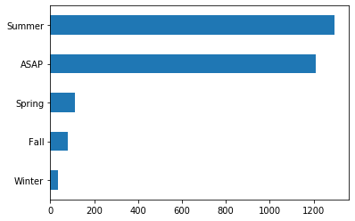

```python
df['Start date'].value_counts()[0:5].sort_values(ascending=True).plot(kind = 'barh')
```

# 3. Text analysis

```python
pip install wordcloud
```

```python
from textblob import TextBlob
```

```python
data = df.copy()
data.head()
```

|  | Submitted On | Education | Skillset | What do you want to work | Teammate or not | Remotely or not | Start date | Platforms interested in | Pick Your Startups | Pick Your Teams | How you can add value | Biggest Achievement | Your ideal job | What we know about you that we didnt ask you | Unnamed: 14 |
| --- | --- | --- | --- | --- | --- | --- | --- | --- | --- | --- | --- | --- | --- | --- | --- |
| 0 | 1 | Santa Clara University | More than technical skills, I would say am goo... | My prior experience was different from what I ... | Doesn't matter. | If it’s an option, I don't mind working remotely. | NaN | NaN | NaN | NaN | NaN | nan | nan | NaN | NaN |
| 1 | 2 | University of California, Riverside | In regards to my talents, I have a strong bac... | I hope to work in the data science field to p... | Working as a team or working by myself are bot... | Commuting to and from work is not an issue sin... | NaN | NaN | NaN | NaN | NaN | nan | nan | NaN | NaN |
| 2 | 3 | University of California, Berkeley | I have exceptional time management skills. As ... | Though I am relatively new to programming as I... | Though I believe I am able to handle either, I... | No, I will not be working remotely. | NaN | NaN | NaN | NaN | NaN | nan | nan | NaN | NaN |
| 3 | 4 | San Jose State University | I am goo with Back-end development and Machine... | I want to work on any kind of software develop... | Doesn't Matter, but prefer working on team | I am fine with anything | NaN | NaN | NaN | NaN | NaN | nan | nan | NaN | NaN |
| 4 | 5 | University of California, San Diego | I'm talented at self-control. I would finish m... | I would like to know more people in the workpl... | I would prefer working individually on a small... | Because I'm still studying in UC San Diego, I ... | NaN | NaN | NaN | NaN | NaN | nan | nan | NaN | NaN |

# What do you want to work on?

```python
data['What do you want to work']=data['What do you want to work'].astype(str)
```

```python
import gc # garbage collector

from collections import Counter # for counting commong words
from os import path
from PIL import Image
from wordcloud import WordCloud, STOPWORDS, ImageColorGenerator
import re # regular expression
import string # for finding punctuation in text
import nltk # preprocessing text
nltk.download('stopwords')
```

```
True
```

```python
def preprocess(x):
    x = re.sub('[^a-z\s]', '', x.lower())                  # get rid of noise
    x = [w for w in x.split() if w not in set(stopwords)]  # remove stopwords
    return ' '.join(x) # then join the text again
# let's find out which stopwords need to remove. We'll use english stopwords.
i = nltk.corpus.stopwords.words('english')
# punctuations to remove
j = list(string.punctuation)
# finally let's combine all of these
stopwords = set(i).union(j)
data['text_clear'] = data['What do you want to work'].apply(preprocess)

def sentiment(x):
    sentiment = TextBlob(x)
    return sentiment.sentiment.polarity

data['senti_polarity'] = data['text_clear'].apply(sentiment)
```

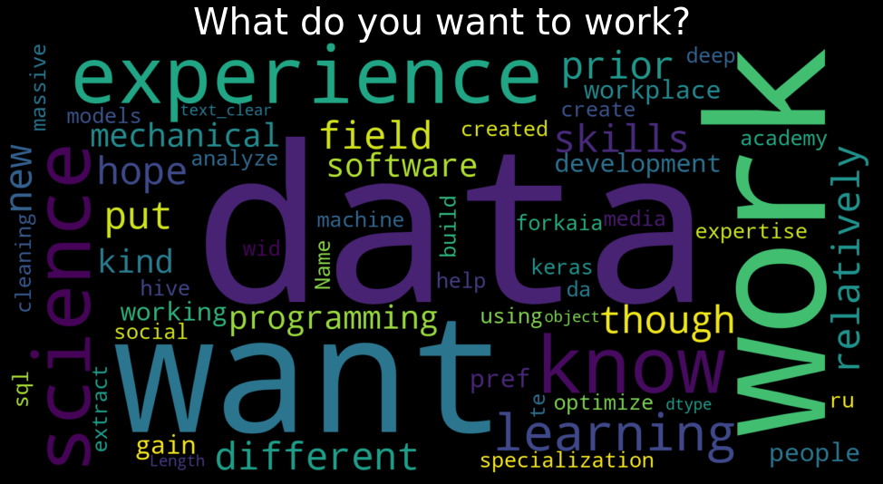

```python
# define wordcloud function from wordcloud library. set some parameteres for beatuful plotting
wc = WordCloud(width=1600, height=800, random_state=1, max_words=200000000)
# generate word cloud
wc.generate(str(data['text_clear']))
# figure of graph
plt.figure(figsize=(20,10), facecolor='k')
# add the title to the graph
plt.title("What do you want to work?", fontsize=40,color='white')
plt.imshow(wc, interpolation='bilinear')
plt.axis('off')
plt.tight_layout(pad=10)
# finally show the plot
plt.show()
```

Candidates would like to work on data science and analysis as well as programming, software development and SQL, hive, deep learning, mechanical.

# Skillset

```python
data['Skillset']=data['Skillset'].astype(str)
```

```python
def preprocess(x):
    x = re.sub('[^a-z\s]', '', x.lower())                  # get rid of noise
    x = [w for w in x.split() if w not in set(stopwords)]  # remove stopwords
    return ' '.join(x) # then join the text again
# let's find out which stopwords need to remove. We'll use english stopwords.
i = nltk.corpus.stopwords.words('english')
# punctuations to remove
j = list(string.punctuation)
# finally let's combine all of these
stopwords = set(i).union(j)
data['text_clear'] = data['Skillset'].apply(preprocess)

def sentiment(x):
    sentiment = TextBlob(x)
    return sentiment.sentiment.polarity

data['senti_polarity'] = data['text_clear'].apply(sentiment)
```

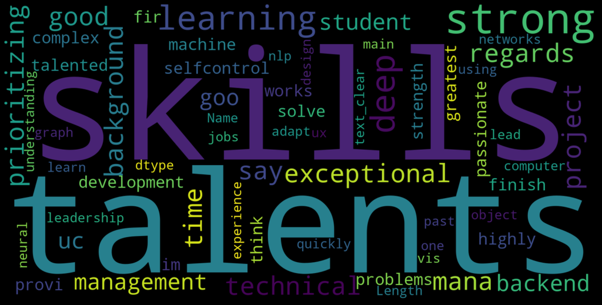

```python
# define wordcloud function from wordcloud library. set some parameteres for beatuful plotting
wc = WordCloud(width=1600, height=800, random_state=1, max_words=200000000)
# generate word cloud
wc.generate(str(data['text_clear']))
# figure of graph
plt.figure(figsize=(20,10), facecolor='k')
# add the title to the graph

plt.imshow(wc, interpolation='bilinear')
plt.axis('off')
plt.tight_layout(pad=10)
# finally show the plot
plt.show()
```

Most hightlighted skills include: neural network, deep learning, computer science, backend, project & time management, self-control, problem solving.

# Most picked Startups

```python
data['Pick Your Startups']=data['Pick Your Startups'].astype(str)
```

```python
#drop null
data.dropna(subset=['Pick Your Startups'], inplace=True)
```

```python
def preprocess(x):
    x = re.sub('[^a-z\s]', '', x.lower())                  # get rid of noise
    x = [w for w in x.split() if w not in set(stopwords)]  # remove stopwords
    return ' '.join(x) # then join the text again
# let's find out which stopwords need to remove. We'll use english stopwords.
i = nltk.corpus.stopwords.words('english')
# punctuations to remove
j = list(string.punctuation)
# finally let's combine all of these
stopwords = set(i).union(j)
data['text_clear'] = data['Pick Your Startups'].apply(preprocess)

def sentiment(x):
    sentiment = TextBlob(x)
    return sentiment.sentiment.polarity

data['senti_polarity'] = data['text_clear'].apply(sentiment)
```

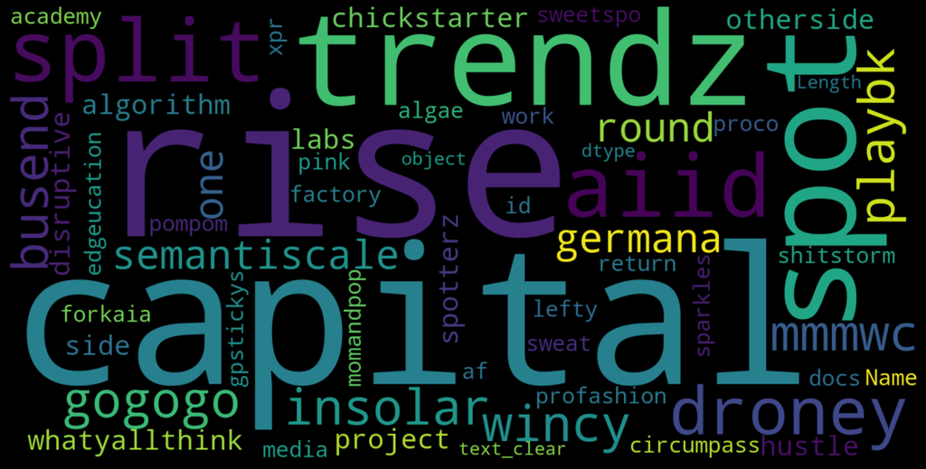

```python
# define wordcloud function from wordcloud library. set some parameteres for beatuful plotting
wc = WordCloud(width=1600, height=800, random_state=1, max_words=200000000)
# generate word cloud
wc.generate(str(data['text_clear']))
# figure of graph
plt.figure(figsize=(20,10), facecolor='k')
# add the title to the graph

plt.imshow(wc, interpolation='bilinear')
plt.axis('off')
plt.tight_layout(pad=10)
# finally show the plot
plt.show()
```

# How you can add value

```python
#drop null
data.dropna(subset=['How you can add value'], inplace=True)
```

```python
data['How you can add value']=data['How you can add value'].astype(str)
```

```python
def preprocess(x):
    x = re.sub('[^a-z\s]', '', x.lower())                  # get rid of noise
    x = [w for w in x.split() if w not in set(stopwords)]  # remove stopwords
    return ' '.join(x) # then join the text again
# let's find out which stopwords need to remove. We'll use english stopwords.
i = nltk.corpus.stopwords.words('english')
# punctuations to remove
j = list(string.punctuation)
# finally let's combine all of these
stopwords = set(i).union(j)
data['text_clear'] = data['How you can add value'].apply(preprocess)

def sentiment(x):
    sentiment = TextBlob(x)
    return sentiment.sentiment.polarity

data['senti_polarity'] = data['text_clear'].apply(sentiment)
```

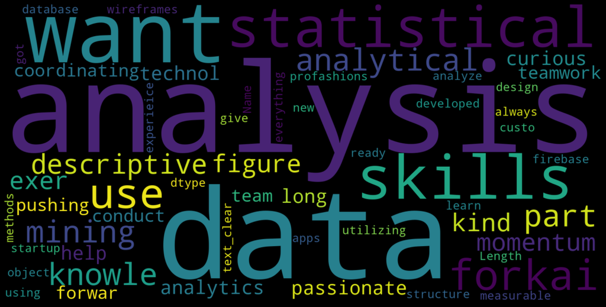

```python
# define wordcloud function from wordcloud library. set some parameteres for beatuful plotting
wc = WordCloud(width=1600, height=800, random_state=1, max_words=200000000)
# generate word cloud
wc.generate(str(data['text_clear']))
# figure of graph
plt.figure(figsize=(20,10), facecolor='k')
# add the title to the graph

plt.imshow(wc, interpolation='bilinear')
plt.axis('off')
plt.tight_layout(pad=10)
# finally show the plot
plt.show()
```

Candidates would like to contribute to the company by their skillsets in statistics, data analysis, data mining. They also would like to show their passion and teamwork as soft skills.

# What we know about you that we didnt ask you

```python
#drop null
data.dropna(subset=['What we know about you that we didnt ask you'], inplace=True)
```

```python
data['What we know about you that we didnt ask you']=data['What we know about you that we didnt ask you'].astype(str)
```

```python
def preprocess(x):
    x = re.sub('[^a-z\s]', '', x.lower())                  # get rid of noise
    x = [w for w in x.split() if w not in set(stopwords)]  # remove stopwords
    return ' '.join(x) # then join the text again
# let's find out which stopwords need to remove. We'll use english stopwords.
i = nltk.corpus.stopwords.words('english')
# punctuations to remove
j = list(string.punctuation)
# finally let's combine all of these
stopwords = set(i).union(j)
data['text_clear'] = data['What we know about you that we didnt ask you'].apply(preprocess)

def sentiment(x):
    sentiment = TextBlob(x)
    return sentiment.sentiment.polarity

data['senti_polarity'] = data['text_clear'].apply(sentiment)
```

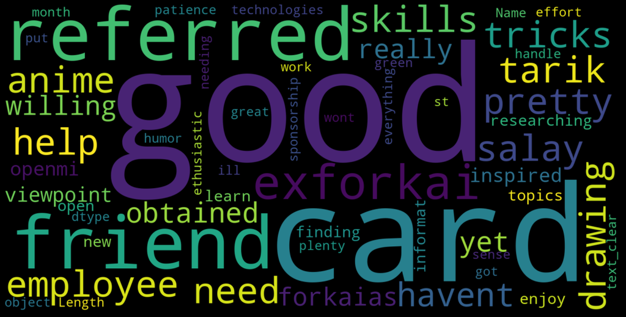

```python
# define wordcloud function from wordcloud library. set some parameteres for beatuful plotting
wc = WordCloud(width=1600, height=800, random_state=1, max_words=200000000)
# generate word cloud
wc.generate(str(data['text_clear']))
# figure of graph
plt.figure(figsize=(20,10), facecolor='k')
# add the title to the graph

plt.imshow(wc, interpolation='bilinear')
plt.axis('off')
plt.tight_layout(pad=10)
# finally show the plot
plt.show()
```

# Biggest Achievement

```python
#drop null
data.dropna(subset=['Biggest Achievement'], inplace=True)
```

```python
data['Biggest Achievement']=data['Biggest Achievement'].astype(str)
```

```python
def preprocess(x):
    x = re.sub('[^a-z\s]', '', x.lower())                  # get rid of noise
    x = [w for w in x.split() if w not in set(stopwords)]  # remove stopwords
    return ' '.join(x) # then join the text again
# let's find out which stopwords need to remove. We'll use english stopwords.
i = nltk.corpus.stopwords.words('english')
# punctuations to remove
j = list(string.punctuation)
# finally let's combine all of these
stopwords = set(i).union(j)
data['text_clear'] = data['Biggest Achievement'].apply(preprocess)

def sentiment(x):
    sentiment = TextBlob(x)
    return sentiment.sentiment.polarity

data['senti_polarity'] = data['text_clear'].apply(sentiment)
```

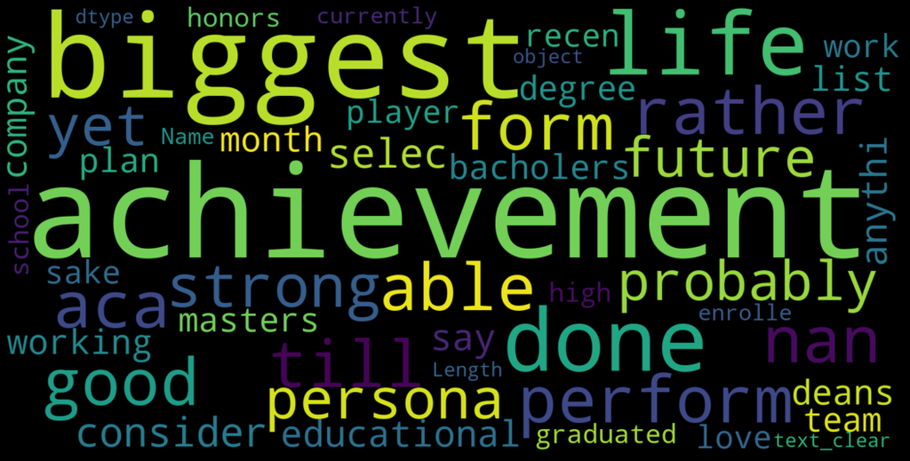

```python
# define wordcloud function from wordcloud library. set some parameteres for beatuful plotting
wc = WordCloud(width=1600, height=800, random_state=1, max_words=200000000)
# generate word cloud
wc.generate(str(data['text_clear']))
# figure of graph
plt.figure(figsize=(20,10), facecolor='k')
# add the title to the graph

plt.imshow(wc, interpolation='bilinear')
plt.axis('off')
plt.tight_layout(pad=10)
# finally show the plot
plt.show()
```

Regarding biggest achievement, candidates shared a lot about their educational achievement such as master degree, bachelors degree, dean list, honors awards. They also had good performance in their past experience, projects or some moments in life.